# Assignment 2 - Social Network Analysis

## Part I

Start by installing the “igraph” package. Once you have installed igraph, load the package.

```r
library("igraph")
library("dplyr")
```

Now upload the data file “discipline-data.csv” as a data frame called “D1”. Each row is a disciplinary action from a teacher to a student so the first line shows that teacher “E” sent student “21” to the principal. It also shows the gender of both the teacher and student and the student’s main elective field of study (“major”“) and the field that the teacher instructs in (”t.expertise“).

```r
setwd("~/Documents/GitHub/EDM Class/assignment2")
D1 <- read.csv("Data/discipline-data.csv")
```

Before you proceed, you will need to change the data type of the student id variable. Since it is a number R will automatically think it is an integer and code it as such (look at the list of variables by clicking on the data frame arrow in the Data pane. Here you will see the letters “int”" next to the stid variable, that stands for integer). However, in this case we are treating the variable as a category, there is no numeric meaning in the variable. So we need to change the format to be a category, what R calls a “factor”. We can do this with the following code:

```r
D1$stid <- as.factor(D1$stid)
```

igraph requires data to be in a particular structure. There are several structures that it can use but we will be using a combination of an “edge list” and a “vertex list”. As you might imagine the edge list contains a list of all the relationships between students and teachers and any characteristics of those edges that we might be interested in. There are two essential variables in the edge list a “from” variable and a “to” variable that descibe the relationships between vertices (a disciplinary action is given “from” and teacher “to” a student). While the vertix list contains all the characteristics of those vertices, in our case gender and major.

So let’s convert our data into an edge list!

First we will isolate the variables that are of interest: tid and stid

Since our data represnts every time a teacher sends a student to the principal there are multiple rows when the same teacher sends the same student. We want to collapse these into a single row, with a variable that shows how many times a teacher-student pair appears.

```r
D2 <- dplyr::select(D1, tid, stid)

EDGE <- dplyr::count(D2, tid, stid)
names(EDGE) <- c("from", "to", "count")
```

```r
EDGE1 <- dplyr::count(D2, tid, stid)
#notes: n is like weight in the tutorial

EDGE1 <- aggregate(EDGE1[,3], EDGE1[,-3], sum)
EDGE1 <- EDGE1[order(EDGE1$tid, EDGE1$stid),]
names(EDGE1) <- c("from", "to", "count")

#notes: gives the same result, but why does this jumble up the row numbers?
```

EDGE is your edge dataframe. Now we need to make the vertex dataframe, a df of all the teachers and students and their characteristics in our network.

```r
#First we will separate the teachers from our original data frame
V.TCH <- dplyr::select(D1, tid, t.gender, t.expertise)
V.TCH
```

```
##    tid t.gender t.expertise
## 1    E   female         art
## 2    A   female     biology
## 3    A   female     biology
## 4    E   female         art
## 5    D   female         art
## 6    E   female         art
## 7    B     male        math
## 8    E   female         art
## 9    A   female     biology
## 10   C     male     biology
## 11   D   female         art
## 12   B     male        math
## 13   D   female         art
## 14   A   female     biology
```

[output cut: 42 more lines]

```r
#Remove all the repeats so that we just have a list of each teacher and their characteristics
V.TCH <- unique(V.TCH)
V.TCH
```

```
##    tid t.gender t.expertise
## 1    E   female         art
## 2    A   female     biology
## 5    D   female         art
## 7    B     male        math
## 10   C     male     biology
```

```r
#Add a variable that describes that they are teachers
V.TCH$group <- "teacher"
V.TCH
```

```
##    tid t.gender t.expertise   group
## 1    E   female         art teacher
## 2    A   female     biology teacher
## 5    D   female         art teacher
## 7    B     male        math teacher
## 10   C     male     biology teacher
```

```r
#Now repeat this process for the students
V.STD <- dplyr::select(D1, stid, s.gender, s.major)
V.STD <- unique(V.STD)
V.STD$group <- "student"
V.STD
```

```
##    stid s.gender s.major   group
## 1    21   female     art student
## 2     4     male    math student
## 3    25     male biology student
## 4    15   female english student
## 5     1     male biology student
## 6     8     male english student
## 10   10     male     art student
## 12   26   female     art student
## 13   23   female     art student
## 14    3     male     art student
## 17   27   female     art student
## 18   29   female     art student
## 19    5     male     art student
## 21   18     male biology student
## 22   28     male    math student
## 23   11     male     art student
## 24   17     male biology student
## 28    9     male biology student
## 33   12   female     art student
## 34   24     male     art student
## 41   22   female biology student
## 42    2   female    math student
## 43   19   female biology student
## 45    6     male biology student
## 48   20     male biology student
```

```r
#Make sure that the student and teacher data frames have the same variables names
#note: although they are different groups, their id should still be named "id"
#note:the columns for the two types of vertices must be identical, i.e. the two types of vertices should have the same types of vertex attributes, because you are going to rbind them after.
names(V.TCH) <- c("id", "gender", "topic", "group")
names(V.STD) <- c("id", "gender", "topic", "group")

#Bind the two data frames together (you will get a warning because the teacher data frame has 5 types of id (A,B,C,D,E) and the student has 25 (1-30), this isn't a problem)
VERTEX <- bind_rows(V.TCH, V.STD)
VERTEX
```

```
##    id gender   topic   group
## 1   E female     art teacher
## 2   A female biology teacher
## 3   D female     art teacher
## 4   B   male    math teacher
## 5   C   male biology teacher
## 6  21 female     art student
## 7   4   male    math student
## 8  25   male biology student
## 9  15 female english student
## 10  1   male biology student
## 11  8   male english student
## 12 10   male     art student
## 13 26 female     art student
## 14 23 female     art student
```

[output cut: 16 more lines]

```r
class(VERTEX)
```

```
## [1] "data.frame"
```

Now we have both a Vertex and Edge list it is time to plot our graph!

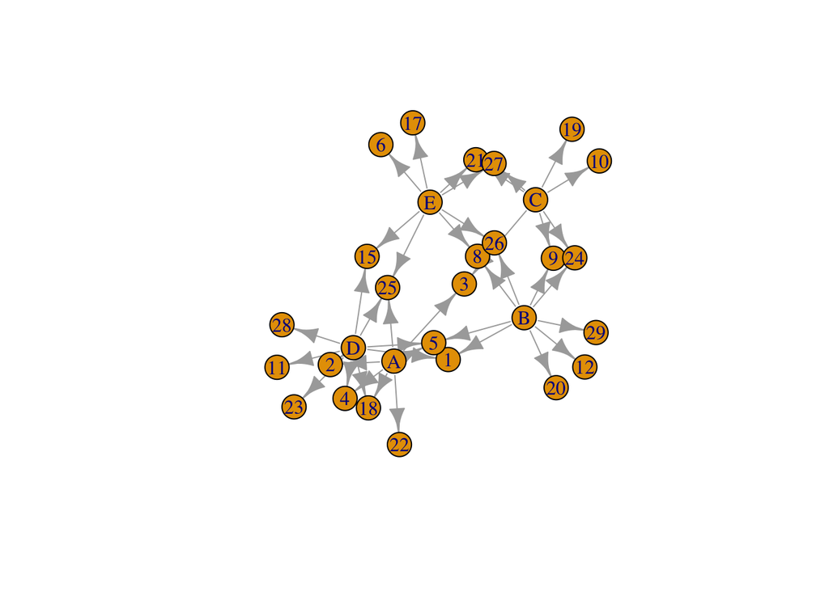

```r
#Load the igraph package

library(igraph)

#First we will make an object that contains the graph information using our two dataframes EDGE and VERTEX. Notice that we have made "directed = TRUE" - our graph is directed since discipline is being given from a teacher to a student.

g <- graph.data.frame(EDGE, vertices=VERTEX, directed=TRUE)

#Now we can plot our graph using the force directed graphing technique - our old friend Fruchertman-Reingold!

plot(g,layout=layout.fruchterman.reingold)
```

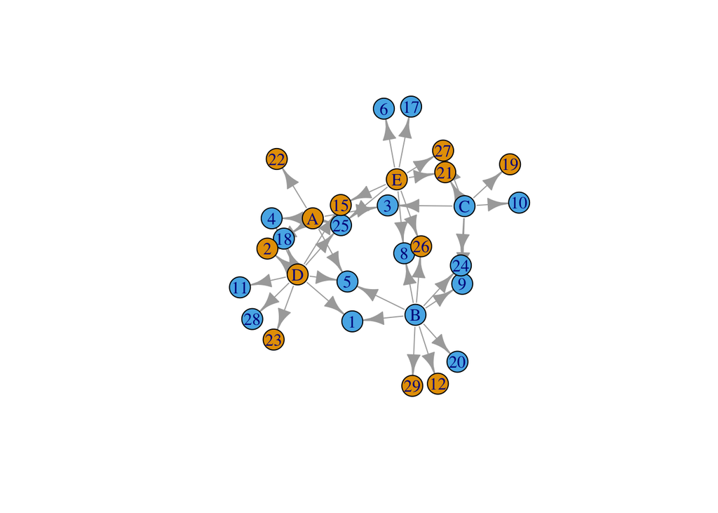

```r
#There are many ways to change the attributes of the graph to represent different characteristics of the newtork. For example, we can color the nodes according to gender.

plot(g,layout=layout.fruchterman.reingold, vertex.color=VERTEX$gender)
```

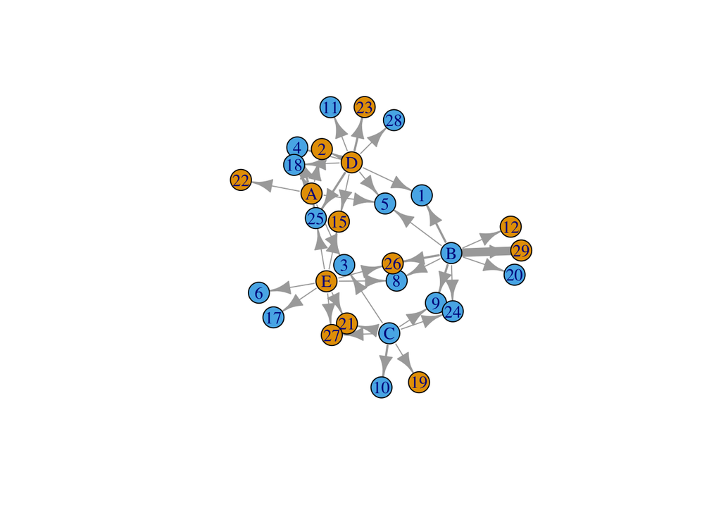

```r
#Question: are the gender colors by default?

#We can change the thickness of the edge according to the number of times a particular teacher has sent a particular student to the principal.

plot(g,layout=layout.fruchterman.reingold, vertex.color=VERTEX$gender, edge.width=EDGE$count)
```

## Part II

In Part II your task is to [look up](http://igraph.org/r/) in the igraph documentation and create a graph that sizes the student vertices in terms of the number of disciplinary actions they have recieved, and the teachers in terms of the number of disciplinary actions they have given out.

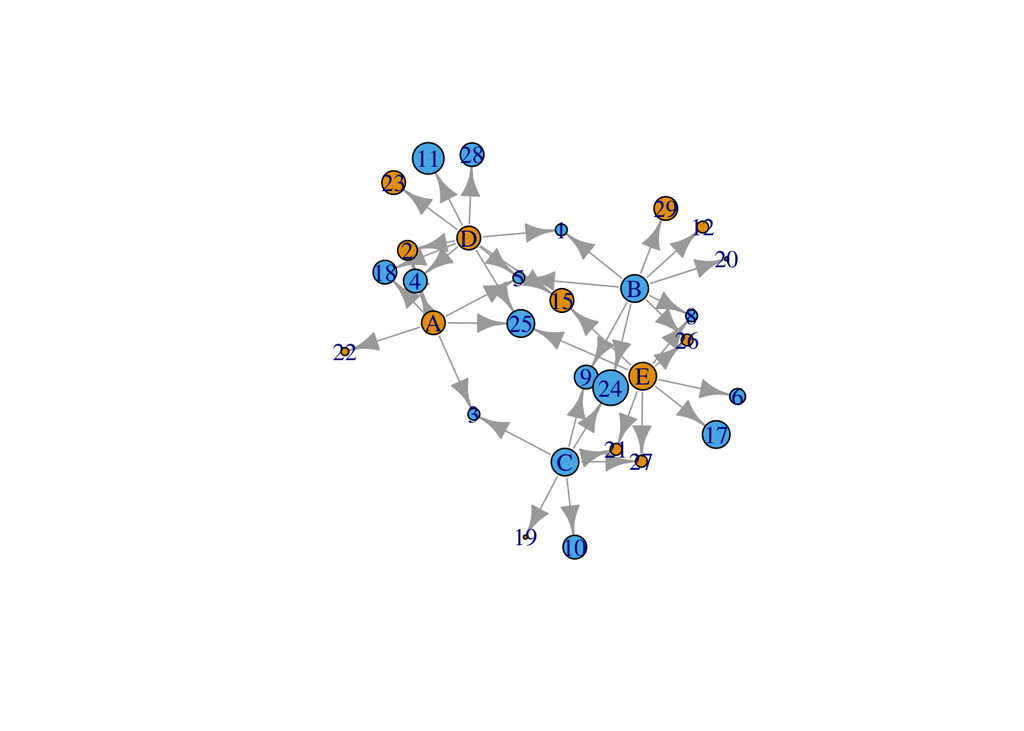

```r
stud_count_df <- EDGE %>%
  dplyr::group_by(to) %>%
  dplyr::summarise(sum(count)) %>%
  as.matrix()

teacher_count_df <- EDGE %>%
  dplyr::group_by(from) %>%
  dplyr::summarise(sum(count)) %>%
  as.matrix()

combined_count <- rbind(stud_count_df, teacher_count_df)

combined_count <- as.data.frame(combined_count)
combined_count$`sum(count)` <- as.numeric(combined_count$`sum(count)`)

V(g)$size <- combined_count$`sum(count)`*2

plot(g, vertex.color=VERTEX$gender)
```

## Part III

Now practice with data from our class. Please create a **person-network** with the data set hudk4050-classes.csv. To create this network you will need to create a person-class matrix using the tidyr functions and then create a person-person matrix using `t()`. You will then need to plot a matrix rather than a data frame using igraph.

```r
DF_class <- DF_class %>%
  select("First_N" = Q8, "Last_N" = Q9, "UNI" = Q10, "Class 1" = Q1, "Class 2" = Q3, "Class 3" = Q4, "Class 4" = Q5, "Class 5" = Q6, "Class 6" = Q7) %>%
  unite(Name, First_N, Last_N, sep = " ")

DF_class <- DF_class[-c(1,2), ]

for (i in 3:8){
  DF_class[,i] <- gsub( " ", "", DF_class[,i])
}

DF_class[DF_class=="4050"] <- "HUDK4050"
DF_class[DF_class=="4125"] <- "HUDM4125"
DF_class[DF_class=="QMSS-5072"] <- "QMSS5072"
DF_class[DF_class=="5126"] <- "HUDM5126"
DF_class[DF_class== c("G5067", "QMSSGR5067")] <- "QMSS5067"
DF_class[DF_class=="G5072"] <- "QMSS5072"
DF_class[DF_class=="HUDK4050"] <- ""

#rename: 4050 -> HUDK4050, 4125 -> HUDM4125, QMSS-5072 -> QMSS5072,  5126 -> HUDM5126, G5067 -> QMSS5067, G5072 > QMSS5072, QMSSGR5067 -> QMSS5067
#left it: 5026 - not sure which dept
#remove: HUDK4050 -> ""

DF_class <- gather(DF_class, ClassNo, Classes, 3:8)
DF_class <- DF_class[order(DF_class$Name),]

DF_class <- DF_class[!(DF_class$Classes == ""), ] %>%
  select(Name, Classes)

DF_class$attend <- 1

DF_class <- DF_class %>%
  spread(Classes, attend)

DF_class[is.na(DF_class)] <- 0

rownames(DF_class) <- DF_class$Name

DF_class <- DF_class %>%
  select(-Name)

DF_class_matrix <- as.matrix(DF_class)
adj_matrix <- DF_class_matrix %*% t(DF_class_matrix)
adj_matrix
```

```
##                   Alysandra Zhang Anqi Duan Artemas Wang Beibei Cao
## Alysandra Zhang                 2         0            0          0
## Anqi Duan                       0         3            1          0
## Artemas Wang                    0         1            2          0
## Beibei Cao                      0         0            0          3
## Bernell Downer                  0         1            1          0
## chaoxiong chen                  0         1            1          0
## Chengxuan Hu                    0         0            1          0
## Chenyu Yan                      2         1            1          0
## Christine Odenath               0         0            0          0
## David Pearce                    0         0            1          0
## Di Mao                          0         0            1          0
## Eudora Xinyi Niu                0         0            0          0
## HAN GE                          0         1            1          0
## Han Wang                        0         0            0          0
## INDIRA BATAYEVA                 0         0            0          0
## jiahao guo                      0         0            1          0
## Jiancong  Shen                  0         1            1          0
## Jie Chen                        0         1            1          0
## Jingru Zhang                    0         0            0          0
## Joellyn Heng                    0         0            0          0
## Leonardo Restrepo               0         2            2          0
## Ling Ai                         0         0            0          0
## LINGLING MIAO                   0         0            1          0
## Lintong Li                      0         1            2          0
## Luyi Dai                        0         0            1          0
## Maho Hayashi                    0         1            0          0
## Minruo Wang                     1         0            0          0
## Ningyao Xu                      0         0            1          0
## Qiyang Lin                      1         0            0          0
## Ruiqi Wang                      0         0            1          0
## Shijie  Shao                    0         0            1          0
## Suwon  Jung                     0         1            1          0
## Timothy Lee                     0         1            1          0
## Wanruo Zhang                    0         1            1          0
## XI YANG                         0         0            1          0
## Xiaowen Chen                    0         1            1          0
## xinyi zhou                      1         1            1          0
## XUDIAN ZHANG                    0         0            1          0
## YAQI LU                         0         0            0          0
```

[output cut: 569 more lines]

```
## xinyi zhou                     2               1         0          0
## XUDIAN ZHANG                   0               1         2          3
## YAQI LU                        0               0         0          0
## Yawei Zhu                      1               1         0          0
## Yigao Liu                      0               0         0          0
## Yiwei Qi                       0               0         0          0
## Yiwen Ma                       0               1         2          3
## yixiao li                      0               0         0          0
## Yixuan Zhu                     1               1         0          0
## Yiyi Xie                       2               1         0          0
## Yujun Zhang                    1               2         0          1
## Zhaozhuo Zheng                 3               1         0          0
## Zhongyuan Zhang                1               3         0          1
## ZIMO CHEN                      0               0         3          2
## Ziyuan Guo                     0               1         2          3
```

```r
network <- graph_from_adjacency_matrix(adj_matrix)
network
```

```
## IGRAPH 68896a5 DN-- 51 1488 --
## + attr: name (v/c)
## + edges from 68896a5 (vertex names):
##  [1] Alysandra Zhang->Alysandra Zhang Alysandra Zhang->Alysandra Zhang
##  [3] Alysandra Zhang->Chenyu Yan      Alysandra Zhang->Chenyu Yan
##  [5] Alysandra Zhang->Minruo Wang     Alysandra Zhang->Qiyang Lin
##  [7] Alysandra Zhang->xinyi zhou      Alysandra Zhang->Yiyi Xie
##  [9] Alysandra Zhang->Zhaozhuo Zheng  Anqi Duan      ->Anqi Duan
## [11] Anqi Duan      ->Anqi Duan       Anqi Duan      ->Anqi Duan
## [13] Anqi Duan      ->Artemas Wang    Anqi Duan      ->Bernell Downer
## [15] Anqi Duan      ->chaoxiong chen  Anqi Duan      ->Chenyu Yan
## + ... omitted several edges
```

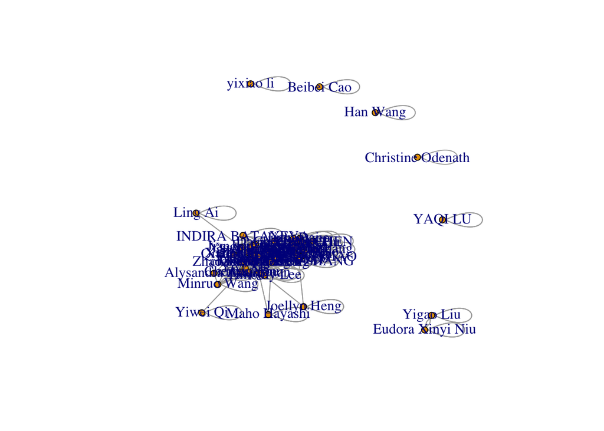

```r
E(network)$arrow.mode <- 0
networks <- simplify(network)
plot(networks, vertex.size = 5)
```

Once you have done this, also [look up](http://igraph.org/r/) how to generate the following network metrics: betweeness centrality and dregree. **Who is the most central person in the network?**

```r
deg <- degree(networks, mode="in")
max(deg)
```

```
## [1] 51
```

```r
deg[deg == 51]
```

```
## Lintong Li
##         51
```

```r
centr_degree(networks, mode="in", normalized=T)
```

```
## $res
##  [1]  9 27 39  3 37 34 47 32  1 32 48  5 36  2 17 47 34 34 30  7 42  4 47
## [24] 51 47  6  9 47 22 49 47 33 24 36 47 35 30 49  3 23  5  3 47  3 35 29
## [47] 45 30 42 30 47
##
## $centralization
## [1] 0.4364706
##
## $theoretical_max
## [1] 2550
```

Lintong Li is the most central person.